# Cardiovascular Disease Prediction: Data Analysis and Machine Learning Model Development.

### Importing necessary libraries

```python
import pandas as pd
import seaborn as sns
import matplotlib.pyplot as plt
import numpy as np
df=pd.read_csv('Desktop/cardio_train.csv')
df
```

|  | id | age | gender | height | weight | ap_hi | ap_lo | cholesterol | gluc | smoke | alco | active | cardio |
| --- | --- | --- | --- | --- | --- | --- | --- | --- | --- | --- | --- | --- | --- |
| 0 | 0 | 18393 | 2 | 168 | 62.0 | 110 | 80 | 1 | 1 | 0 | 0 | 1 | 0 |
| 1 | 1 | 20228 | 1 | 156 | 85.0 | 140 | 90 | 3 | 1 | 0 | 0 | 1 | 1 |
| 2 | 2 | 18857 | 1 | 165 | 64.0 | 130 | 70 | 3 | 1 | 0 | 0 | 0 | 1 |
| 3 | 3 | 17623 | 2 | 169 | 82.0 | 150 | 100 | 1 | 1 | 0 | 0 | 1 | 1 |
| 4 | 4 | 17474 | 1 | 156 | 56.0 | 100 | 60 | 1 | 1 | 0 | 0 | 0 | 0 |
| ... | ... | ... | ... | ... | ... | ... | ... | ... | ... | ... | ... | ... | ... |
| 69995 | 99993 | 19240 | 2 | 168 | 76.0 | 120 | 80 | 1 | 1 | 1 | 0 | 1 | 0 |
| 69996 | 99995 | 22601 | 1 | 158 | 126.0 | 140 | 90 | 2 | 2 | 0 | 0 | 1 | 1 |
| 69997 | 99996 | 19066 | 2 | 183 | 105.0 | 180 | 90 | 3 | 1 | 0 | 1 | 0 | 1 |
| 69998 | 99998 | 22431 | 1 | 163 | 72.0 | 135 | 80 | 1 | 2 | 0 | 0 | 0 | 1 |
| 69999 | 99999 | 20540 | 1 | 170 | 72.0 | 120 | 80 | 2 | 1 | 0 | 0 | 1 | 0 |

70000 rows × 13 columns

## Comprehensive Data Preprocessing for Cardiovascular Health Analysis.

### Data Summarization

```python
df.head()
```

|  | id | age | gender | height | weight | ap_hi | ap_lo | cholesterol | gluc | smoke | alco | active | cardio |
| --- | --- | --- | --- | --- | --- | --- | --- | --- | --- | --- | --- | --- | --- |
| 0 | 0 | 18393 | 2 | 168 | 62.0 | 110 | 80 | 1 | 1 | 0 | 0 | 1 | 0 |
| 1 | 1 | 20228 | 1 | 156 | 85.0 | 140 | 90 | 3 | 1 | 0 | 0 | 1 | 1 |
| 2 | 2 | 18857 | 1 | 165 | 64.0 | 130 | 70 | 3 | 1 | 0 | 0 | 0 | 1 |
| 3 | 3 | 17623 | 2 | 169 | 82.0 | 150 | 100 | 1 | 1 | 0 | 0 | 1 | 1 |
| 4 | 4 | 17474 | 1 | 156 | 56.0 | 100 | 60 | 1 | 1 | 0 | 0 | 0 | 0 |

```python
df.tail()
```

|  | id | age | gender | height | weight | ap_hi | ap_lo | cholesterol | gluc | smoke | alco | active | cardio |
| --- | --- | --- | --- | --- | --- | --- | --- | --- | --- | --- | --- | --- | --- |
| 69995 | 99993 | 19240 | 2 | 168 | 76.0 | 120 | 80 | 1 | 1 | 1 | 0 | 1 | 0 |
| 69996 | 99995 | 22601 | 1 | 158 | 126.0 | 140 | 90 | 2 | 2 | 0 | 0 | 1 | 1 |
| 69997 | 99996 | 19066 | 2 | 183 | 105.0 | 180 | 90 | 3 | 1 | 0 | 1 | 0 | 1 |
| 69998 | 99998 | 22431 | 1 | 163 | 72.0 | 135 | 80 | 1 | 2 | 0 | 0 | 0 | 1 |
| 69999 | 99999 | 20540 | 1 | 170 | 72.0 | 120 | 80 | 2 | 1 | 0 | 0 | 1 | 0 |

```python
df.info()
```

```
<class 'pandas.core.frame.DataFrame'>
RangeIndex: 70000 entries, 0 to 69999
Data columns (total 13 columns):
 #   Column       Non-Null Count  Dtype
---  ------       --------------  -----
 0   id           70000 non-null  int64
 1   age          70000 non-null  int64
 2   gender       70000 non-null  int64
 3   height       70000 non-null  int64
 4   weight       70000 non-null  float64
 5   ap_hi        70000 non-null  int64
 6   ap_lo        70000 non-null  int64
 7   cholesterol  70000 non-null  int64
 8   gluc         70000 non-null  int64
 9   smoke        70000 non-null  int64
 10  alco         70000 non-null  int64
 11  active       70000 non-null  int64
 12  cardio       70000 non-null  int64
dtypes: float64(1), int64(12)
memory usage: 6.9 MB
```

```python
df.shape
```

```
(70000, 13)
```

```python
df.columns
```

```
Index(['id', 'age', 'gender', 'height', 'weight', 'ap_hi', 'ap_lo',
       'cholesterol', 'gluc', 'smoke', 'alco', 'active', 'cardio'],
      dtype='object')
```

```python
df.describe() .T
```

|  | count | mean | std | min | 25% | 50% | 75% | max |
| --- | --- | --- | --- | --- | --- | --- | --- | --- |
| id | 70000.0 | 49972.419900 | 28851.302323 | 0.0 | 25006.75 | 50001.5 | 74889.25 | 99999.0 |
| age | 70000.0 | 19468.865814 | 2467.251667 | 10798.0 | 17664.00 | 19703.0 | 21327.00 | 23713.0 |
| gender | 70000.0 | 1.349571 | 0.476838 | 1.0 | 1.00 | 1.0 | 2.00 | 2.0 |
| height | 70000.0 | 164.359229 | 8.210126 | 55.0 | 159.00 | 165.0 | 170.00 | 250.0 |
| weight | 70000.0 | 74.205690 | 14.395757 | 10.0 | 65.00 | 72.0 | 82.00 | 200.0 |
| ap_hi | 70000.0 | 128.817286 | 154.011419 | -150.0 | 120.00 | 120.0 | 140.00 | 16020.0 |
| ap_lo | 70000.0 | 96.630414 | 188.472530 | -70.0 | 80.00 | 80.0 | 90.00 | 11000.0 |
| cholesterol | 70000.0 | 1.366871 | 0.680250 | 1.0 | 1.00 | 1.0 | 2.00 | 3.0 |
| gluc | 70000.0 | 1.226457 | 0.572270 | 1.0 | 1.00 | 1.0 | 1.00 | 3.0 |
| smoke | 70000.0 | 0.088129 | 0.283484 | 0.0 | 0.00 | 0.0 | 0.00 | 1.0 |
| alco | 70000.0 | 0.053771 | 0.225568 | 0.0 | 0.00 | 0.0 | 0.00 | 1.0 |
| active | 70000.0 | 0.803729 | 0.397179 | 0.0 | 1.00 | 1.0 | 1.00 | 1.0 |
| cardio | 70000.0 | 0.499700 | 0.500003 | 0.0 | 0.00 | 0.0 | 1.00 | 1.0 |

### Value counts:

```python
# Value counts of age
df.value_counts(['age'])

#Data Manipulation (Converting age in Years from Days)
df.drop('id',axis=1,inplace=True)

df['age']=(df['age']/365).astype(int)

df.head()
```

|  | age | gender | height | weight | ap_hi | ap_lo | cholesterol | gluc | smoke | alco | active | cardio |
| --- | --- | --- | --- | --- | --- | --- | --- | --- | --- | --- | --- | --- |
| 0 | 50 | 2 | 168 | 62.0 | 110 | 80 | 1 | 1 | 0 | 0 | 1 | 0 |
| 1 | 55 | 1 | 156 | 85.0 | 140 | 90 | 3 | 1 | 0 | 0 | 1 | 1 |
| 2 | 51 | 1 | 165 | 64.0 | 130 | 70 | 3 | 1 | 0 | 0 | 0 | 1 |
| 3 | 48 | 2 | 169 | 82.0 | 150 | 100 | 1 | 1 | 0 | 0 | 1 | 1 |
| 4 | 47 | 1 | 156 | 56.0 | 100 | 60 | 1 | 1 | 0 | 0 | 0 | 0 |

```python
df['gender'].replace({1:'Male', 2:'Female'}, inplace=True)
df.value_counts(['gender'])
```

```
gender
Male      45530
Female    24470
Name: count, dtype: int64
```

```python
df.value_counts(['height'])
```

```
height
165       5853
160       5022
170       4679
168       4399
164       3396
          ...
113          1
119          1
122          1
128          1
250          1
Name: count, Length: 109, dtype: int64
```

```python
df.value_counts(['weight'])
```

```
weight
65.0      3850
70.0      3764
68.0      2831
75.0      2740
60.0      2710
          ...
70.7         1
70.8         1
94.7         1
94.5         1
10.0         1
Name: count, Length: 287, dtype: int64
```

```python
df.value_counts(['ap_hi'])
```

```
ap_hi
120      27699
140       9506
130       8961
110       8644
150       4450
         ...
207          1
230          1
309          1
401          1
16020        1
Name: count, Length: 153, dtype: int64
```

```python
df.value_counts(['ap_lo'])
```

```
ap_lo
80       34847
90       14316
70       10245
100       4082
60        2727
         ...
910          1
1002         1
1007         1
1022         1
11000        1
Name: count, Length: 157, dtype: int64
```

```python
df['cholesterol'].replace({1:'normal', 2:'above normal',3:'well above normal'}, inplace=True)
df.value_counts(['cholesterol'])
```

```
cholesterol
normal               52385
above normal          9549
well above normal     8066
Name: count, dtype: int64
```

```python
df['gluc'].replace({1:'normal', 2:'above normal',3:'well above normal'}, inplace=True)
df.value_counts(['gluc'])
```

```
gluc
normal               59479
well above normal     5331
above normal          5190
Name: count, dtype: int64
```

```python
 df['smoke'].replace({0:'No', 1:'Yes'}, inplace=True)
df.value_counts(['smoke'])
```

```
smoke
No       63831
Yes       6169
Name: count, dtype: int64
```

```python
df['alco'].replace({0:'No', 1:'Yes'}, inplace=True)
df.value_counts(['alco'])
```

```
alco
No      66236
Yes      3764
Name: count, dtype: int64
```

```python
df['active'].replace({0:'No', 1:'Yes'}, inplace=True)
df.value_counts(['active'])
```

```
active
Yes       56261
No        13739
Name: count, dtype: int64
```

```python
df['cardio'].replace({0:'No', 1:'Yes'}, inplace=True)
df.value_counts(['cardio'])
```

```
cardio
No        35021
Yes       34979
Name: count, dtype: int64
```

```python
df.nunique()
```

```
age             28
gender           2
height         109
weight         287
ap_hi          153
ap_lo          157
cholesterol      3
gluc             3
smoke            2
alco             2
active           2
cardio           2
dtype: int64
```

```python
df.isnull().sum()
```

```
age            0
gender         0
height         0
weight         0
ap_hi          0
ap_lo          0
cholesterol    0
gluc           0
smoke          0
alco           0
active         0
cardio         0
dtype: int64
```

# Data Analysis

## Exploratory Data Analysis (EDA) & Univariate Analysis.

### Purpose: To explore and understand relationships and patterns between variables, and to identify potential trends, correlations or anomalies, also To understand the distribution and characteristics of individual variables.

#### A.) Gender Distribution

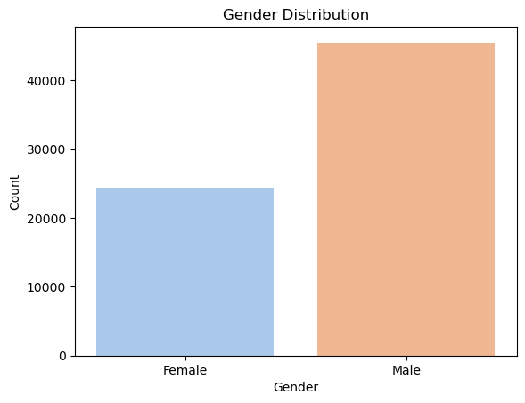

```python
sns.countplot(x='gender',hue='gender',data=df, palette='pastel')
plt.title('Gender Distribution')
plt.xlabel('Gender')
plt.ylabel('Count')
plt.show()
```

#### The bar chart indicates that the dataset contains more males than females, with the male category having a significantly higher count.

#### B.)Cardiovascular Disease Proportion.

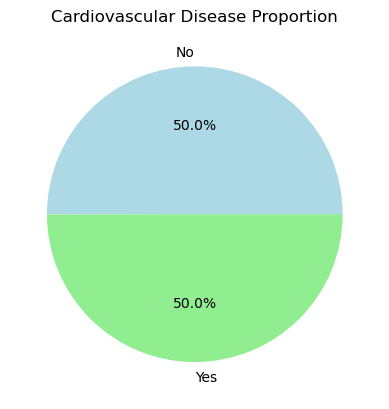

```python
df['cardio'].value_counts().plot.pie (autopct='%1.1f%%',colors=['lightblue', 'lightgreen'])
plt. title('Cardiovascular Disease Proportion')
plt. ylabel('')
plt. show()
```

#### The pie chart shows a 50/50 split between individuals with (light green) and without (light blue) cardiovascular disease, indicating a balanced distribution.

#### C.)Cholesterol Levels by Gender.

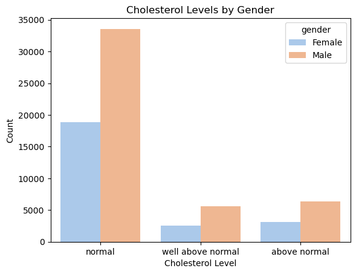

```python
sns.countplot(x='cholesterol',hue='gender', data=df, palette='pastel')
plt. title( 'Cholesterol Levels by Gender')
plt. xlabel( 'Cholesterol Level')
plt. ylabel( 'Count' )
plt. show()
```

#### The bar chart displays cholesterol levels by gender, revealing that males have higher counts in both normal and above-normal categories, with a significant lead in the normal range. In contrast, females have lower counts across all levels, with the majority falling within the normal category.

#### D.)Smoking Status by Gender.

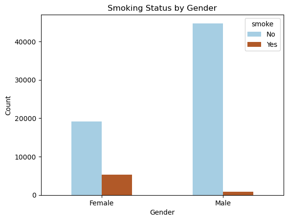

```python
smoking_gender = pd.crosstab(df['gender'], df['smoke'])

smoking_gender.plot(kind='bar', colormap='Paired')

plt.title('Smoking Status by Gender')
plt.xlabel('Gender')
plt.ylabel('Count')
plt.xticks(rotation=0)
plt.show()
```

#### E.)Average Age by Cholesterol Level.

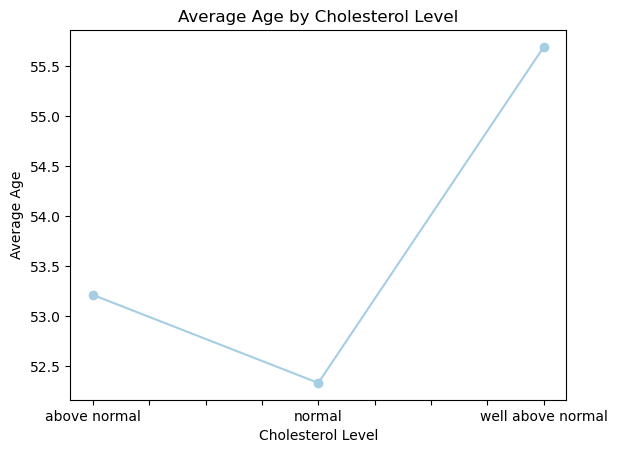

```python
avg_age_by_cholesterol = df.groupby('cholesterol')['age'].mean()

avg_age_by_cholesterol.plot(kind='line', marker='o', colormap='Paired')

plt.title('Average Age by Cholesterol Level')
plt.xlabel('Cholesterol Level')
plt.ylabel('Average Age')
plt.show()
```

#### F.)Average Systolic Blood Pressure by Cardiovascular Disease.

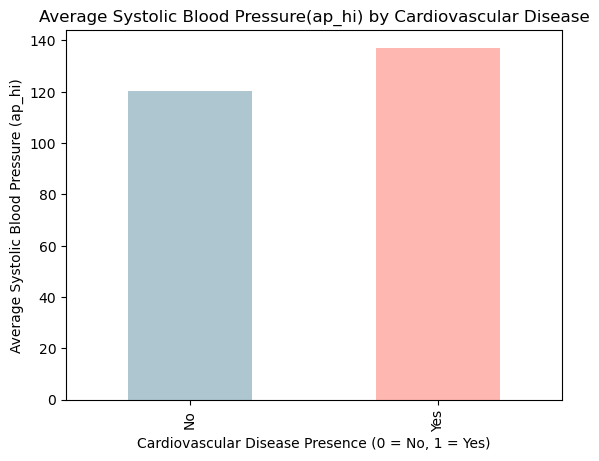

```python
avg_bp_by_cardio = df.groupby('cardio')['ap_hi'].mean()

avg_bp_by_cardio.plot(kind='bar', color=['#AEC6CF', '#FFB7B2'])

plt.title('Average Systolic Blood Pressure(ap_hi) by Cardiovascular Disease')
plt.xlabel('Cardiovascular Disease Presence (0 = No, 1 = Yes)')
plt.ylabel('Average Systolic Blood Pressure (ap_hi)')
plt.show()
```

#### G.)Age Distribution by Cardiovascular Disease Presence.

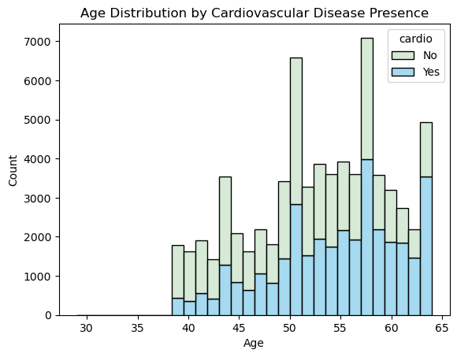

```python
sns.histplot(data=df, x='age',hue='cardio', multiple='stack', bins=30,palette=["#C9E4CA","#87CEEB"])
plt.title( 'Age Distribution by Cardiovascular Disease Presence')
plt.xlabel ( 'Age')
plt.ylabel( 'Count' )
plt.show()
```

#### H.)Cholesterol Levels among Groups (With/Without Cardiovascular Disease).

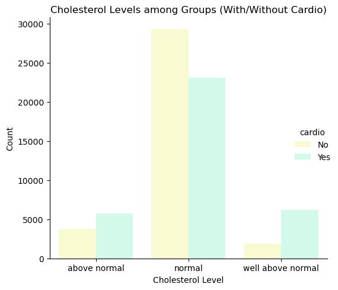

```python
grouped_data = df.groupby(['cholesterol', 'cardio']).size().reset_index(name='count')
colors = ['#ffffcc','#ccffeb']
plt.figure(figsize=(10, 6))
sns.catplot(x='cholesterol', y='count', hue='cardio',kind='bar',palette=colors, data=grouped_data)
plt.title('Cholesterol Levels among Groups (With/Without Cardio)')
plt.xlabel('Cholesterol Level')
plt.ylabel('Count')
plt.tight_layout()
plt.show()
```

#### The plot shows a clear link between cholesterol levels and cardiovascular disease. Most people have normal cholesterol, but those with higher levels are more likely to have cardiovascular disease. As cholesterol levels rise, so does the risk of cardiovascular disease, with the highest risk seen in those with well above normal levels.

#### I.)Relationship between Glucose Levels and Cardiovascular Disease.

```python
df['gluc']=df['gluc'].replace({1: 'normal', 2: 'above normal', 3: 'well above normal' })
pd.crosstab(df.gluc,df.cardio)
```

| cardio gluc | No | Yes |
| --- | --- | --- |
| above normal | 2112 | 3078 |
| normal | 30894 | 28585 |
| well above normal | 2015 | 3316 |

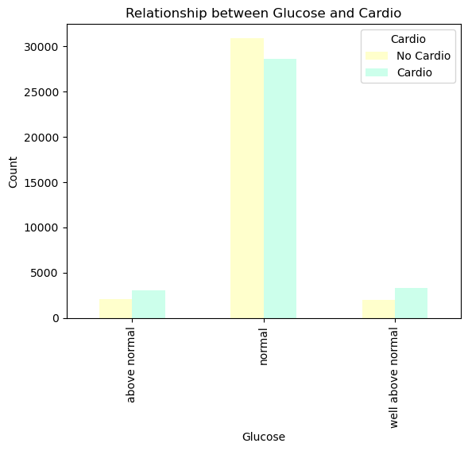

```python
cross_tab = pd.crosstab(df['gluc'], df['cardio'])
cross_tab.plot(kind='bar', color=colors)

plt.title('Relationship between Glucose and Cardio')
plt.xlabel('Glucose')
plt.ylabel('Count')
plt.legend(title='Cardio', labels=['No Cardio', 'Cardio'])

plt.show()
```

#### The plot shows a significant link between glucose levels and cardiovascular disease. Normal glucose levels are more common in those without cardiovascular disease, while above normal and well above normal levels are more prevalent in those with cardiovascular disease, indicating a clear correlation between glucose levels and cardiovascular disease risk.

#### J.)Relationship between Height and Cardiovascular Disease (Males vs Females).

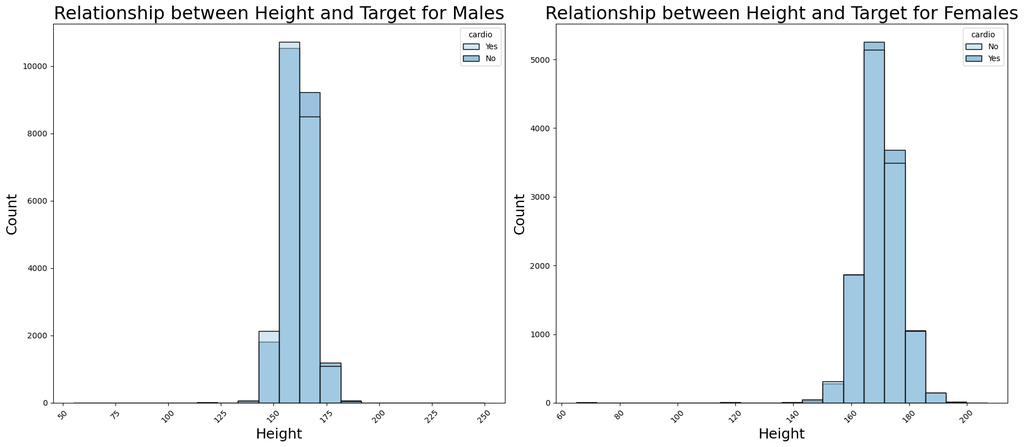

```python
# Filter data by gender
male_data = df[df['gender'] == 'Male'].copy()
female_data = df[df['gender'] == 'Female'].copy()


male_data.loc[:, 'height'] = male_data['height'].round(1)
female_data.loc[:, 'height'] = female_data['height'].round(1)


fig, axes = plt.subplots(1, 2, figsize=(18, 8))

# Histplot for males
sns.histplot(x='height', hue='cardio', data=male_data, bins=20, palette='Blues', ax=axes[0])
axes[0].set_title('Relationship between Height and Target for Males', fontsize=23)
axes[0].set_xlabel('Height', fontsize=18)
axes[0].set_ylabel('Count', fontsize=18)
axes[0].tick_params(axis='x', labelrotation=45)

# Histplot for females
sns.histplot(x='height', hue='cardio', data=female_data, bins=20, palette='Blues', ax=axes[1])
axes[1].set_title('Relationship between Height and Target for Females', fontsize=23)
axes[1].set_xlabel('Height', fontsize=18)
axes[1].set_ylabel('Count', fontsize=18)
axes[1].tick_params(axis='x', labelrotation=45)

plt.tight_layout()
plt.show()
```

#### Two histograms show the relationship between height and cardiovascular disease presence for males and females.

#### Males (left):

- Height range: 50-250 units
- Peak concentration: 150-175 units

#### Females (right):

- Similar height range
- Fewer observations, but same peak concentration (150-175 units)